# Project - Quran Ayah Correction Chatbot **(LAB)** 👨🏻‍💻📖

## 1️⃣ Required Libraries

```python
import os
import re
import gc
from collections import Counter


import pandas as pd
import numpy as np
import matplotlib.pyplot as plt
import seaborn as sns


from rapidfuzz import fuzz
from sentence_transformers import SentenceTransformer


from IPython.display import Audio, display

pd.set_option("display.max_colwidth", 160)
plt.style.use("seaborn-v0_8")
```

## 2️⃣ Read Dataset

### Read From GitHub

```python
DATA_URL = "https://raw.githubusercontent.com/malekverse/quran-dataset/main/quran_dataset.csv"
```

```python
df_load = pd.read_csv(DATA_URL)
```

#### 📂 **Project Data Source: Quran Dataset**

##### 1. Overview

This project uses a complete Quran dataset. The dataset contains the Arabic Quran text and metadata for each ayah.

##### 2. Important Columns

| Column | Description |
| --- | --- |
| `surah_no` | Surah number |
| `surah_name_ar` | Arabic surah name |
| `ayah_no_surah` | Ayah number inside the surah |
| `ayah_no_quran` | Global ayah number in the Quran |
| `ayah_ar` | Arabic ayah text |
| `ayah_en` | English translation |

##### 3. Project Goal

The goal is to build a chatbot that corrects Quran ayah input by retrieving the closest correct ayah from the dataset.

The model is used for retrieval only. It does not generate Quranic text.

### Split to Columns

```python
df = df_load.rename(
    columns={
        "surah_name_ar": "surah_name",
        "ayah_no_surah": "ayah_number",
        "ayah_ar": "text",
    }
)

df = df[
    [
        "surah_no",
        "surah_name",
        "ayah_number",
        "ayah_no_quran",
        "text",
        "ayah_en",
    ]
].copy()
```

```python
os.makedirs("data", exist_ok=True)
df.to_csv("data/quran_raw.csv", index=False, encoding="utf-8")
print("Data saved successfully to your disk!")
```

```
Data saved successfully to your disk!
```

```python
df.shape
```

```
(12472, 6)
```

```python
df.head(10)
```

|  | surah_no | surah_name | ayah_number | ayah_no_quran | text | ayah_en |
| --- | --- | --- | --- | --- | --- | --- |
| 0 | 1 | الفاتحة | 1 | 1 | بِسْمِ ٱللَّهِ ٱلرَّحْمَٰنِ ٱلرَّحِيمِ | In the Name of Allah—the Most Compassionate, Most Merciful. |
| 1 | 1 | الفاتحة | 2 | 2 | ٱلْحَمْدُ لِلَّهِ رَبِّ ٱلْعَٰلَمِينَ | All praise is for Allah—Lord of all worlds, |
| 2 | 1 | الفاتحة | 3 | 3 | ٱلرَّحْمَٰنِ ٱلرَّحِيمِ | the Most Compassionate, Most Merciful, |
| 3 | 1 | الفاتحة | 4 | 4 | مَٰلِكِ يَوْمِ ٱلدِّينِ | Master of the Day of Judgment. |
| 4 | 1 | الفاتحة | 5 | 5 | إِيَّاكَ نَعْبُدُ وَإِيَّاكَ نَسْتَعِينُ | You ˹alone˺ we worship and You ˹alone˺ we ask for help. |
| 5 | 1 | الفاتحة | 6 | 6 | ٱهْدِنَا ٱلصِّرَٰطَ ٱلْمُسْتَقِيمَ | Guide us along the Straight Path, |
| 6 | 1 | الفاتحة | 7 | 7 | صِرَٰطَ ٱلَّذِينَ أَنْعَمْتَ عَلَيْهِمْ غَيْرِ ٱلْمَغْضُوبِ عَلَيْهِمْ وَلَا ٱلضَّآلِّينَ | the Path of those You have blessed—not those You are displeased with, or those who are astray. |
| 7 | 2 | البقرة | 1 | 8 | الٓمٓ | Alif-Lãm-Mĩm. |
| 8 | 2 | البقرة | 2 | 9 | ذَٰلِكَ ٱلْكِتَٰبُ لَا رَيْبَ ۛ فِيهِ ۛ هُدًۭى لِّلْمُتَّقِينَ | This is the Book! There is no doubt about it |
| 9 | 2 | البقرة | 3 | 10 | ٱلَّذِينَ يُؤْمِنُونَ بِٱلْغَيْبِ وَيُقِيمُونَ ٱلصَّلَوٰةَ وَمِمَّا رَزَقْنَٰهُمْ يُنفِقُونَ | who believe in the unseen, establish prayer, and donate from what We have provided for them, |

```python
if "df_load" in locals():
    del df_load
gc.collect()
```

```
1938
```

## 3️⃣ Exploratory Data Analysis (EDA)

### Information

```python
df.info()
```

```
<class 'pandas.core.frame.DataFrame'>
RangeIndex: 12472 entries, 0 to 12471
Data columns (total 6 columns):
 #   Column         Non-Null Count  Dtype
---  ------         --------------  -----
 0   surah_no       12472 non-null  int64
 1   surah_name     12472 non-null  object
 2   ayah_number    12472 non-null  int64
 3   ayah_no_quran  12472 non-null  int64
 4   text           12472 non-null  object
 5   ayah_en        12472 non-null  object
dtypes: int64(3), object(3)
memory usage: 584.8+ KB
```

### Check Columns

```python
df.columns
```

```
Index(['surah_no', 'surah_name', 'ayah_number', 'ayah_no_quran', 'text',
       'ayah_en'],
      dtype='object')
```

### Description

```python
df.describe(include='all')
```

|  | surah_no | surah_name | ayah_number | ayah_no_quran | text | ayah_en |
| --- | --- | --- | --- | --- | --- | --- |
| count | 12472.000000 | 12472 | 12472.000000 | 12472.000000 | 12472 | 12472 |
| unique | NaN | 114 | NaN | NaN | 6065 | 6092 |
| top | NaN | البقرة | NaN | NaN | فَبِأَىِّ ءَالَآءِ رَبِّكُمَا تُكَذِّبَانِ | Then which of your Lord’s favours will you both deny? |
| freq | NaN | 572 | NaN | NaN | 62 | 60 |
| mean | 33.519724 | NaN | 53.506575 | 3118.500000 | NaN | NaN |
| std | 26.460200 | NaN | 50.461901 | 1800.250289 | NaN | NaN |
| min | 1.000000 | NaN | 1.000000 | 1.000000 | NaN | NaN |
| 25% | 11.000000 | NaN | 16.000000 | 1559.750000 | NaN | NaN |
| 50% | 26.000000 | NaN | 38.000000 | 3118.500000 | NaN | NaN |
| 75% | 51.000000 | NaN | 75.000000 | 4677.250000 | NaN | NaN |
| max | 114.000000 | NaN | 286.000000 | 6236.000000 | NaN | NaN |

### Check Duplications

```python
print("Duplicated rows:", df.duplicated().sum())
print("Duplicated global ayah numbers:", df.duplicated("ayah_no_quran").sum())
```

```
Duplicated rows: 6236
Duplicated global ayah numbers: 6236
```

```python
df.drop_duplicates(subset=["ayah_no_quran"], keep="first", inplace=True)
df.reset_index(drop=True, inplace=True)
df.shape
```

```
(6236, 6)
```

### Check Missing Values

```python
df.isna().sum()
```

```
surah_no         0
surah_name       0
ayah_number      0
ayah_no_quran    0
text             0
ayah_en          0
dtype: int64
```

### Show Number of Unique Values

```python
for col in df.columns:
    print("{} : {} unique value(s)".format(col, df[col].nunique()))
```

```
surah_no : 114 unique value(s)
surah_name : 114 unique value(s)
ayah_number : 286 unique value(s)
ayah_no_quran : 6236 unique value(s)
text : 6065 unique value(s)
ayah_en : 6092 unique value(s)
```

### Show Most Commen in Columns

```python
top_surahs = df["surah_name"].value_counts().head(15).reset_index()
top_surahs.columns = ["Surah", "Number of Ayahs"]
top_surahs
```

|  | Surah | Number of Ayahs |
| --- | --- | --- |
| 0 | البقرة | 286 |
| 1 | الشعراء | 227 |
| 2 | الأعراف | 206 |
| 3 | آل عمران | 200 |
| 4 | الصافات | 182 |
| 5 | النساء | 176 |
| 6 | الأنعام | 165 |
| 7 | طه | 135 |
| 8 | التوبة | 129 |
| 9 | النحل | 128 |
| 10 | هود | 123 |
| 11 | المائدة | 120 |
| 12 | المؤمنون | 118 |
| 13 | الأنبياء | 112 |
| 14 | يوسف | 111 |

```python
all_words = " ".join(df["text"].astype(str)).split()
word_counts = Counter(all_words)

top_words = pd.DataFrame(word_counts.most_common(15), columns=["Word", "Frequency"])
top_words
```

|  | Word | Frequency |
| --- | --- | --- |
| 0 | ۚ | 1972 |
| 1 | ۖ | 1682 |
| 2 | فِى | 1098 |
| 3 | ٱللَّهِ | 830 |
| 4 | ٱلَّذِينَ | 810 |
| 5 | ٱللَّهُ | 733 |
| 6 | مِن | 728 |
| 7 | مَا | 711 |
| 8 | لَا | 616 |
| 9 | إِنَّ | 609 |
| 10 | وَلَا | 605 |
| 11 | ۗ | 603 |
| 12 | ٱللَّهَ | 592 |
| 13 | إِلَّا | 562 |
| 14 | وَمَا | 512 |

### Make Columns Length of Sentence

```python
df["number_of_characters_ayah"] = df["text"].astype(str).str.len()
df["number_of_words_ayah"] = df["text"].astype(str).str.split().str.len()
```

```python
print(f"Maximum number of characters in an ayah is: {df['number_of_characters_ayah'].max()}")
print(f"Minimum number of characters in an ayah is: {df['number_of_characters_ayah'].min()}")
print(f"Average number of characters in an ayah is: {df['number_of_characters_ayah'].mean():.2f}")
```

```
Maximum number of characters in an ayah is: 1213
Minimum number of characters in an ayah is: 2
Average number of characters in an ayah is: 113.97
```

#### Distribution of Length Characters

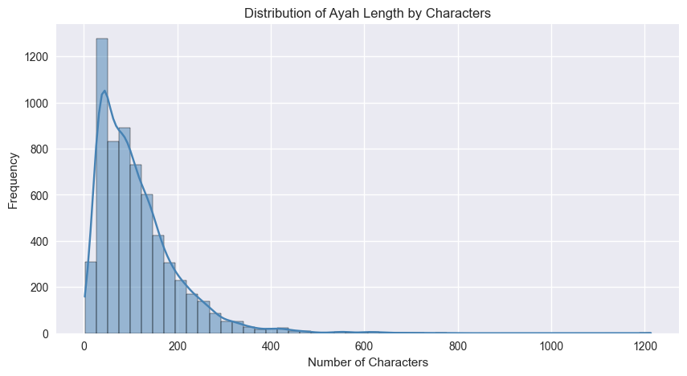

```python
plt.figure(figsize=(10, 5))
sns.histplot(df["number_of_characters_ayah"], bins=50, kde=True, color="steelblue")
plt.title("Distribution of Ayah Length by Characters")
plt.xlabel("Number of Characters")
plt.ylabel("Frequency")
plt.show()
```

#### Distribution of Length Words

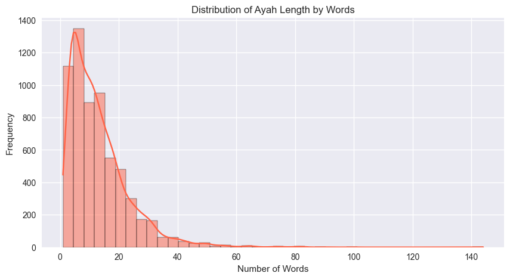

```python
plt.figure(figsize=(10, 5))
sns.histplot(df["number_of_words_ayah"], bins=40, kde=True, color="tomato")
plt.title("Distribution of Ayah Length by Words")
plt.xlabel("Number of Words")
plt.ylabel("Frequency")
plt.show()
```

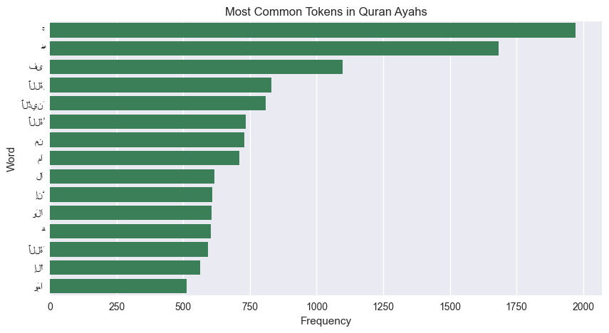

```python
plt.figure(figsize=(10, 5))
sns.barplot(data=top_words, x="Frequency", y="Word", color="seagreen")
plt.title("Most Common Tokens in Quran Ayahs")
plt.xlabel("Frequency")
plt.ylabel("Word")
plt.show()
```

## 4️⃣ Processing

### Clean Texts

```python
def clean_text(text):
    text = str(text)
    text = re.sub(r"http\S+|www\S+|https\S+", "", text)
    text = re.sub(r"\s+", " ", text).strip()
    return text
```

### Arabic Normalization

```python
ARABIC_DIACRITICS_RE = re.compile(
    r"[\u0610-\u061A\u064B-\u065F\u0670\u06D6-\u06ED]"
)


def normalize_arabic(text):
    text = str(text)
    text = ARABIC_DIACRITICS_RE.sub("", text)
    text = re.sub(r"[إأٱآا]", "ا", text)
    text = re.sub(r"ى", "ي", text)
    text = re.sub(r"ؤ", "و", text)
    text = re.sub(r"ئ", "ي", text)
    text = re.sub(r"ة", "ه", text)
    text = re.sub(r"ـ", "", text)
    text = re.sub(r"[^\u0600-\u06FF\s]", " ", text)
    text = re.sub(r"\s+", " ", text).strip()
    return text
```

### Apply Functions

```python
df["text"] = df["text"].apply(clean_text)
df["clean_text"] = df["text"].apply(normalize_arabic)
```

```python
df[["text", "clean_text"]].head()
```

|  | text | clean_text |
| --- | --- | --- |
| 0 | بِسْمِ ٱللَّهِ ٱلرَّحْمَٰنِ ٱلرَّحِيمِ | بسم الله الرحمن الرحيم |
| 1 | ٱلْحَمْدُ لِلَّهِ رَبِّ ٱلْعَٰلَمِينَ | الحمد لله رب العلمين |
| 2 | ٱلرَّحْمَٰنِ ٱلرَّحِيمِ | الرحمن الرحيم |
| 3 | مَٰلِكِ يَوْمِ ٱلدِّينِ | ملك يوم الدين |
| 4 | إِيَّاكَ نَعْبُدُ وَإِيَّاكَ نَسْتَعِينُ | اياك نعبد واياك نستعين |

### Tokenization

```python
model_checkpoint = "sentence-transformers/paraphrase-multilingual-MiniLM-L12-v2"
model = SentenceTransformer(model_checkpoint)

print("Model loaded:", model_checkpoint)
```

```
Model loaded: sentence-transformers/paraphrase-multilingual-MiniLM-L12-v2
```

```python
sample_texts = df["clean_text"].head(3).tolist()
sample_embeddings = model.encode(sample_texts, normalize_embeddings=True)

print("Sample embeddings shape:", sample_embeddings.shape)
```

```
Sample embeddings shape: (3, 384)
```

### Convert DF To Dataset

```python
retrieval_dataset = df[
    [
        "surah_no",
        "surah_name",
        "ayah_number",
        "ayah_no_quran",
        "text",
        "clean_text",
    ]
].copy()

retrieval_dataset.head()
```

|  | surah_no | surah_name | ayah_number | ayah_no_quran | text | clean_text |
| --- | --- | --- | --- | --- | --- | --- |
| 0 | 1 | الفاتحة | 1 | 1 | بِسْمِ ٱللَّهِ ٱلرَّحْمَٰنِ ٱلرَّحِيمِ | بسم الله الرحمن الرحيم |
| 1 | 1 | الفاتحة | 2 | 2 | ٱلْحَمْدُ لِلَّهِ رَبِّ ٱلْعَٰلَمِينَ | الحمد لله رب العلمين |
| 2 | 1 | الفاتحة | 3 | 3 | ٱلرَّحْمَٰنِ ٱلرَّحِيمِ | الرحمن الرحيم |
| 3 | 1 | الفاتحة | 4 | 4 | مَٰلِكِ يَوْمِ ٱلدِّينِ | ملك يوم الدين |
| 4 | 1 | الفاتحة | 5 | 5 | إِيَّاكَ نَعْبُدُ وَإِيَّاكَ نَسْتَعِينُ | اياك نعبد واياك نستعين |

```python
os.makedirs("data", exist_ok=True)
retrieval_dataset.to_csv("data/quran.csv", index=False, encoding="utf-8")
print("Processed retrieval dataset saved successfully!")
```

```
Processed retrieval dataset saved successfully!
```

### Spliting Data

```python
test_cases = [

    # صح من القرآن
    {
        "query": "الحمد لله رب العالمين",
        "surah_name": "الفاتحة",
        "ayah_number": 2,
    },

    {
        "query": "اهدنا الصراط المستقيم",
        "surah_name": "الفاتحة",
        "ayah_number": 6,
    },

    {
        "query": "قل هو الله احد",
        "surah_name": "الإخلاص",
        "ayah_number": 1,
    },

    {
        "query": "من شر الوسواس الخناس",
        "surah_name": "الناس",
        "ayah_number": 4,
    },

    # غلط / غير موجودة حرفيًا
    {
        "query": "الله يحب المتقين دائما",
        "surah_name": "البقرة",
        "ayah_number": 195,
    },

    {
        "query": "الصبر مفتاح الفرج",
        "surah_name": "الشرح",
        "ayah_number": 6,
    },

    {
        "query": "اطلب العلم من المهد الى اللحد",
        "surah_name": "العلق",
        "ayah_number": 1,
    },

]
```

### Expanded Test Set

The first manual test set is small. To get a more realistic evaluation, we create a larger automatic test set from the Quran dataset.

The generated test set includes:

- Full ayah without diacritics.
- First phrase from the ayah.
- Middle phrase from long ayahs.
- A noisy phrase with a small character deletion.

Ambiguous exact phrases that appear in multiple ayahs are filtered when possible.

```python
def make_typo_query(words):
    words = words.copy()
    if not words:
        return ""

    longest_index = max(range(len(words)), key=lambda i: len(words[i]))
    word = words[longest_index]

    if len(word) <= 4:
        return " ".join(words)

    remove_index = len(word) // 2
    words[longest_index] = word[:remove_index] + word[remove_index + 1:]
    return " ".join(words)


def is_unique_substring(query, corpus_texts):
    return sum(query in text for text in corpus_texts) == 1


def create_expanded_test_cases(dataset, sample_size=80, max_cases=150, random_state=42):
    rng_df = dataset.sample(sample_size, random_state=random_state).reset_index(drop=True)
    corpus_texts = dataset["clean_text"].tolist()
    cases = []
    seen = set()

    for _, row in rng_df.iterrows():
        clean_text = row["clean_text"]
        words = clean_text.split()
        if len(words) < 3:
            continue

        candidate_queries = []

        # Full ayah query without diacritics
        candidate_queries.append(("full_ayah", clean_text))

        # First phrase
        first_phrase = " ".join(words[: min(6, len(words))])
        candidate_queries.append(("first_phrase", first_phrase))

        # Middle phrase for longer ayahs
        if len(words) >= 8:
            start = max(0, len(words) // 2 - 2)
            middle_phrase = " ".join(words[start : start + 5])
            candidate_queries.append(("middle_phrase", middle_phrase))

        # Noisy phrase with a small typo
        noisy_base = words[: min(6, len(words))]
        noisy_phrase = make_typo_query(noisy_base)
        candidate_queries.append(("typo_phrase", noisy_phrase))

        for case_type, query in candidate_queries:
            query = query.strip()
            if len(query.split()) < 3:
                continue

            key = (query, int(row["ayah_no_quran"]))
            if key in seen:
                continue

            if case_type in ["first_phrase", "middle_phrase"] and not is_unique_substring(query, corpus_texts):
                continue

            cases.append(
                {
                    "query": query,
                    "query_type": case_type,
                    "surah_name": row["surah_name"],
                    "ayah_number": int(row["ayah_number"]),
                    "ayah_no_quran": int(row["ayah_no_quran"]),
                }
            )
            seen.add(key)

            if len(cases) >= max_cases:
                return pd.DataFrame(cases)

    return pd.DataFrame(cases)


expanded_test_df = create_expanded_test_cases(
    retrieval_dataset,
    sample_size=80,
    max_cases=150,
    random_state=42,
)

expanded_test_cases = expanded_test_df.to_dict("records")

print("Expanded test cases:", len(expanded_test_cases))
expanded_test_df["query_type"].value_counts()
```

[output not shown]

```python
expanded_test_df.head(10)
```

[output not shown]

## 5️⃣ Modeling

### Preparing

```python
ayah_texts = retrieval_dataset["clean_text"].tolist()
```

```python
def score_text_match(clean_input, clean_text):
    if clean_text.startswith(clean_input):
        return 100.0
    if clean_input in clean_text:
        return 96.0
    return max(
        fuzz.WRatio(clean_input, clean_text),
        fuzz.partial_ratio(clean_input, clean_text),
        fuzz.token_set_ratio(clean_input, clean_text),
    )


def match_priority(clean_input, clean_text):
    if clean_text.startswith(clean_input):
        return 2
    if clean_input in clean_text:
        return 1
    return 0
```

```python
def build_audio_url(ayah_no_quran, edition="ar.alafasy"):
    return f"https://cdn.islamic.network/quran/audio/128/{edition}/{int(ayah_no_quran)}.mp3"
```

### Train Data

```python
ayah_embeddings = model.encode(
    ayah_texts,
    normalize_embeddings=True,
    batch_size=32,
    show_progress_bar=True,
)

ayah_embeddings.shape
```

```
(6236, 384)
```

```python
def find_closest_ayah(user_input, top_k=5, threshold=85):
    clean_input = normalize_arabic(user_input)
    if not clean_input:
        return pd.DataFrame()

    query_embedding = model.encode([clean_input], normalize_embeddings=True)
    semantic_scores = (query_embedding @ ayah_embeddings.T)[0]

    semantic_top_indices = np.argsort(semantic_scores)[::-1][: max(top_k * 8, 40)]

    fuzzy_scores = retrieval_dataset["clean_text"].apply(
        lambda text: score_text_match(clean_input, text)
    ).to_numpy()

    fuzzy_top_indices = np.argsort(fuzzy_scores)[::-1][: max(top_k * 8, 40)]

    candidate_indices = np.array(
        sorted(set(semantic_top_indices.tolist()) | set(fuzzy_top_indices.tolist()))
    )

    candidates = retrieval_dataset.iloc[candidate_indices].copy()

    candidates["semantic_score"] = semantic_scores[candidate_indices]
    candidates["fuzzy_score"] = fuzzy_scores[candidate_indices]

    candidates["match_priority"] = candidates["clean_text"].apply(
        lambda text: match_priority(clean_input, text)
    )

    candidates["final_score"] = (
        candidates["semantic_score"] * 100 * 0.35
        + candidates["fuzzy_score"] * 0.65
    )


    candidates = candidates[candidates["final_score"] >= threshold]

    candidates = candidates.sort_values(
        ["match_priority", "final_score"], ascending=False
    ).head(top_k)

    return candidates[
        [
            "surah_no",
            "surah_name",
            "ayah_number",
            "ayah_no_quran",
            "text",
            "semantic_score",
            "fuzzy_score",
            "final_score",
        ]
    ]
```

### Evaluation

```python
def evaluate_retrieval(test_cases, top_k=5):
    rows = []

    for case in test_cases:
        predictions = find_closest_ayah(case["query"], top_k=top_k).reset_index(drop=True)

        # لو مفيش نتائج
        if predictions.empty:
            rows.append({
                "query": case["query"],
                "expected": f'{case["surah_name"]}:{case["ayah_number"]}',
                "top_prediction": "No prediction",
                "rank": None,
                "top1_correct": False,
                f"recall@{top_k}": 0,
                "reciprocal_rank": 0,
                f"ndcg@{top_k}": 0,
                "top_score": 0,
            })
            continue

        expected_mask = (
            (predictions["surah_name"] == case["surah_name"])
            & (predictions["ayah_number"] == case["ayah_number"])
        ).to_numpy()

        if expected_mask.any():
            rank = int(np.where(expected_mask)[0][0]) + 1
            reciprocal_rank = 1 / rank
            recall_at_k = 1
            ndcg_at_k = 1 / np.log2(rank + 1)
        else:
            rank = None
            reciprocal_rank = 0
            recall_at_k = 0
            ndcg_at_k = 0

        top_prediction = predictions.iloc[0]

        rows.append({
            "query": case["query"],
            "expected": f'{case["surah_name"]}:{case["ayah_number"]}',
            "top_prediction": f'{top_prediction["surah_name"]}:{top_prediction["ayah_number"]}',
            "rank": rank,
            "top1_correct": bool(rank == 1),
            f"recall@{top_k}": recall_at_k,
            "reciprocal_rank": reciprocal_rank,
            f"ndcg@{top_k}": ndcg_at_k,
            "top_score": round(float(top_prediction["final_score"]), 2),
        })

    details = pd.DataFrame(rows)

    summary = pd.DataFrame({
        "Metric": [
            "Top-1 Accuracy",
            f"Recall@{top_k}",
            "MRR",
            "Mean Rank",
            f"nDCG@{top_k}",
        ],
        "Score": [
            details["top1_correct"].mean(),
            details[f"recall@{top_k}"].mean(),
            details["reciprocal_rank"].mean(),
            details["rank"].dropna().mean(),
            details[f"ndcg@{top_k}"].mean(),
        ],
    })

    return details, summary
```

```python
evaluation_details, evaluation_summary = evaluate_retrieval(test_cases, top_k=5)
evaluation_details
```

|  | query | expected | top_prediction | rank | top1_correct | recall@5 | reciprocal_rank | ndcg@5 | top_score |
| --- | --- | --- | --- | --- | --- | --- | --- | --- | --- |
| 0 | الحمد لله رب العالمين | الفاتحة:2 | الفاتحة:2 | 1.0 | True | 1 | 1.0 | 1.0 | 94.58 |
| 1 | اهدنا الصراط المستقيم | الفاتحة:6 | الفاتحة:6 | 1.0 | True | 1 | 1.0 | 1.0 | 97.43 |
| 2 | قل هو الله احد | الإخلاص:1 | الإخلاص:1 | 1.0 | True | 1 | 1.0 | 1.0 | 100.00 |
| 3 | من شر الوسواس الخناس | الناس:4 | الناس:4 | 1.0 | True | 1 | 1.0 | 1.0 | 100.00 |
| 4 | الله يحب المتقين دائما | البقرة:195 | No prediction | NaN | False | 0 | 0.0 | 0.0 | 0.00 |
| 5 | الصبر مفتاح الفرج | الشرح:6 | No prediction | NaN | False | 0 | 0.0 | 0.0 | 0.00 |
| 6 | اطلب العلم من المهد الى اللحد | العلق:1 | No prediction | NaN | False | 0 | 0.0 | 0.0 | 0.00 |

```python
evaluation_summary
```

|  | Metric | Score |
| --- | --- | --- |
| 0 | Top-1 Accuracy | 0.571429 |
| 1 | Recall@5 | 0.571429 |
| 2 | MRR | 0.571429 |
| 3 | Mean Rank | 1.000000 |
| 4 | nDCG@5 | 0.571429 |

```python
def performance_level(metric, score):
    if metric in ["Top-1 Accuracy", "Recall@5"]:
        if score >= 0.90:
            return "Excellent"
        elif score >= 0.75:
            return "Good"
        elif score >= 0.60:
            return "Average"
        else:
            return "Weak"

    elif metric == "MRR":
        if score >= 0.85:
            return "Excellent"
        elif score >= 0.70:
            return "Good"
        elif score >= 0.50:
            return "Average"
        else:
            return "Weak"

    elif metric == "nDCG@5":
        if score >= 0.90:
            return "Excellent"
        elif score >= 0.75:
            return "Good"
        elif score >= 0.60:
            return "Average"
        else:
            return "Weak"

    else:
        return "N/A"


evaluation_summary["Performance Level"] = evaluation_summary.apply(
    lambda row: performance_level(row["Metric"], row["Score"]),
    axis=1
)

evaluation_summary
```

|  | Metric | Score | Performance Level |
| --- | --- | --- | --- |
| 0 | Top-1 Accuracy | 0.571429 | Weak |
| 1 | Recall@5 | 0.571429 | Weak |
| 2 | MRR | 0.571429 | Average |
| 3 | Mean Rank | 1.000000 | N/A |
| 4 | nDCG@5 | 0.571429 | Weak |

```python
def find_embedding_only(user_input, top_k=5):
    clean_input = normalize_arabic(user_input)
    query_embedding = model.encode([clean_input], normalize_embeddings=True)
    semantic_scores = (query_embedding @ ayah_embeddings.T)[0]
    top_indices = np.argsort(semantic_scores)[::-1][:top_k]

    candidates = retrieval_dataset.iloc[top_indices].copy()
    candidates["final_score"] = semantic_scores[top_indices] * 100
    return candidates


def find_fuzzy_only(user_input, top_k=5):
    clean_input = normalize_arabic(user_input)
    fuzzy_scores = retrieval_dataset["clean_text"].apply(
        lambda text: score_text_match(clean_input, text)
    ).to_numpy()

    candidates = retrieval_dataset.copy()
    candidates["fuzzy_score"] = fuzzy_scores
    candidates["match_priority"] = candidates["clean_text"].apply(
        lambda text: match_priority(clean_input, text)
    )
    candidates["final_score"] = candidates["fuzzy_score"]
    return candidates.sort_values(["match_priority", "final_score"], ascending=False).head(top_k)
```

```python
def evaluate_method(method_name, search_function, test_cases, top_k=5):
    rows = []

    for case in test_cases:
        predictions = search_function(case["query"], top_k=top_k).reset_index(drop=True)
        expected_mask = (
            (predictions["surah_name"] == case["surah_name"])
            & (predictions["ayah_number"] == case["ayah_number"])
        ).to_numpy()

        rank = int(np.where(expected_mask)[0][0]) + 1 if expected_mask.any() else None
        rows.append(
            {
                "Method": method_name,
                "Top-1 Accuracy": int(rank == 1),
                f"Recall@{top_k}": int(rank is not None),
                "MRR": 1 / rank if rank else 0,
                f"nDCG@{top_k}": 1 / np.log2(rank + 1) if rank else 0,
            }
        )

    return pd.DataFrame(rows).groupby("Method", as_index=False).mean()
```

```python
comparison_summary = pd.concat(
    [
        evaluate_method("Embedding Only", find_embedding_only, test_cases),
        evaluate_method("Fuzzy Only", find_fuzzy_only, test_cases),
        evaluate_method("Hybrid System", find_closest_ayah, test_cases),
    ],
    ignore_index=True,
)

comparison_summary
```

|  | Method | Top-1 Accuracy | Recall@5 | MRR | nDCG@5 |
| --- | --- | --- | --- | --- | --- |
| 0 | Embedding Only | 0.571429 | 0.571429 | 0.571429 | 0.571429 |
| 1 | Fuzzy Only | 0.285714 | 0.285714 | 0.285714 | 0.285714 |
| 2 | Hybrid System | 0.571429 | 0.571429 | 0.571429 | 0.571429 |

```python
def performance_level(score):

    if score >= 0.90:
        return "Excellent"

    elif score >= 0.75:
        return "Good"

    elif score >= 0.60:
        return "Average"

    else:
        return "Weak"

comparison_results["Level"] = comparison_results["Top-1 Accuracy"].apply(
    performance_level
)

comparison_results
```

[output not shown]

### Evaluation on Expanded Test Set

Now we evaluate the retrieval system on the larger generated test set. This gives a stronger estimate than the small manual test set.

```python
expanded_details, expanded_summary = evaluate_retrieval(expanded_test_cases, top_k=5)
expanded_details.head(10)
```

[output not shown]

```python
expanded_summary
```

[output not shown]

```python
expanded_type_results = expanded_details.groupby("query").size().reset_index(name="count")

expanded_details_with_type = expanded_details.merge(
    expanded_test_df[["query", "query_type"]],
    on="query",
    how="left",
)

expanded_by_type = expanded_details_with_type.groupby("query_type").agg(
    top1_accuracy=("top1_correct", "mean"),
    recall_at_5=("recall@5", "mean"),
    mrr=("reciprocal_rank", "mean"),
    ndcg_at_5=("ndcg@5", "mean"),
    cases=("query", "count"),
).reset_index()

expanded_by_type
```

[output not shown]

```python
plot_expanded = expanded_summary[expanded_summary["Metric"] != "Mean Rank"].copy()

plt.figure(figsize=(9, 4))
sns.barplot(data=plot_expanded, x="Metric", y="Score", color="darkcyan")
plt.ylim(0, 1.05)
plt.title("Expanded Test Set Retrieval Metrics")
plt.xticks(rotation=20)
plt.show()
```

[output not shown]

### Expanded Evaluation Results

To make the evaluation stronger, the test set was expanded from a small manual set to **150 generated test cases**.

The expanded test set contains different query types:

| Query Type | Number of Cases |
| --- | --- |
| Full ayah without diacritics | 49 |
| First phrase | 27 |
| Middle phrase | 30 |
| Typo phrase | 44 |
| **Total** | **150** |

#### Overall Results on Expanded Test Set

| Metric | Score |
| --- | --- |
| **Top-1 Accuracy** | **91.33%** |
| **Recall@5** | **94.67%** |
| **MRR** | **92.63%** |
| **Mean Rank** | **1.07** |
| **nDCG@5** | **93.14%** |

#### Results by Query Type

| Query Type | Cases | Top-1 Accuracy | Recall@5 | MRR | nDCG@5 |
| --- | --- | --- | --- | --- | --- |
| First phrase | 27 | 100.00% | 100.00% | 100.00% | 100.00% |
| Full ayah | 49 | 97.96% | 97.96% | 97.96% | 97.96% |
| Middle phrase | 30 | 100.00% | 100.00% | 100.00% | 100.00% |
| Typo phrase | 44 | 72.73% | 84.09% | 77.16% | 78.89% |

#### Interpretation

The system still performs strongly overall, especially for exact, first phrase, and middle phrase inputs. The most difficult case is the `typo_phrase` category, which is expected because these queries contain artificial spelling errors.

### External Comparison: Same Base Model Family

The base model used in this project is:

```
sentence-transformers/paraphrase-multilingual-MiniLM-L12-v2
```

To evaluate our system more clearly, we compare our results with public reported results from systems that used the same model family or fine-tuned versions of it.

> Important: this is not a perfect direct comparison because the datasets and tasks are different. It is used only as an external reference.

[output not shown]

#### Interpretation

The external systems report `Accuracy@1` between `55.97%` and `89.90%` on their own datasets. Since the datasets and tasks are different, this table should be used as a reference, not as a strict ranking.

The fair internal comparison in this project is:

```
Embedding Only vs Fuzzy Only vs Hybrid System
```

because all three methods are evaluated on the same Quran dataset and the same test cases.

Sources:

- https://huggingface.co/sentence-transformers/paraphrase-multilingual-MiniLM-L12-v2
- https://huggingface.co/ntAnh-dev/paraphrase-multilingual-MiniLM-L12-v2
- https://huggingface.co/SMARTICT/paraphrase-multilingual-MiniLM-L12-v2-ft-tr-rag-v1
- https://huggingface.co/yahyaabd/paraphrase-multilingual-miniLM-L12-V2-v1-2

### Model Results and External Comparison Summary

This table shows the actual performance of our system after expanding the test set to **150 test cases**.

#### Our Model Results

| Metric | Our Result | Evaluation Level |
| --- | --- | --- |
| **Top-1 Accuracy** | **91.33%** | Excellent |
| **Accuracy@5 / Recall@5** | **94.67%** | Excellent |
| **MRR** | **92.63%** | Excellent |
| **Mean Rank** | **1.07** | Excellent |
| **nDCG@5** | **93.14%** | Excellent |

#### Other People Results Using the Same Model Family

| System | Dataset / Task | Accuracy@1 | Accuracy@5 | Recall@5 | MRR@10 | nDCG@10 |
| --- | --- | --- | --- | --- | --- | --- |
| ntAnh-dev MiniLM | Information Retrieval | 82.43% | 97.30% | 58.40% | 88.01% | 81.75% |
| ntAnh-dev MiniLM - Eval 2 | Information Retrieval | 88.99% | 95.41% | 54.14% | 91.64% | 80.43% |
| SMARTICT ft-tr-rag-v1 | Turkish RAG Retrieval | 55.97% | 71.41% | 71.41% | 62.63% | 65.73% |
| yahyaabd v1-2 | Static Table Retrieval | 89.90% | 98.05% | 78.96% | 93.62% | 82.42% |

#### Are Our Results Good?

| Metric | Weak Result | Good (Lab Project) | Excellent | Our Result |
| --- | --- | --- | --- | --- |
| **Top-1 Accuracy** | < 60% | 75% - 90% | 90%+ | **91.33%** |
| **Accuracy@5 / Recall@5** | < 60% | 75% - 90% | 90%+ | **94.67%** |
| **MRR** | < 50% | 70% - 85% | 85%+ | **92.63%** |
| **nDCG@5** | < 60% | 75% - 90% | 90%+ | **93.14%** |

#### Important Note

The external results are not directly comparable because they were evaluated on different datasets and tasks. They are used only as a reference for the same MiniLM sentence-transformer model family.

The most reliable result for this project is our expanded evaluation on **150 Quran Ayah Correction test cases**.

#### 📝 Summary Table: Are your results good?

| Metric | Weak Result | Average Result | Good Result | Excellent Result |
| --- | --- | --- | --- | --- |
| **Top-1 Accuracy** | 0% - 59% | 60% - 74% | 75% - 89% | 90% - 100% |
| **Recall@5** | 0% - 59% | 60% - 74% | 75% - 89% | 90% - 100% |
| **MRR** | 0% - 49% | 50% - 69% | 70% - 84% | 85% - 100% |
| **nDCG@5** | 0% - 59% | 60% - 74% | 75% - 89% | 90% - 100% |

For this Quran ayah retrieval project, **MRR** and **nDCG@5** are more useful than simple accuracy because they evaluate the ranking quality of the returned ayahs.

#### **📊 Quran Ayah Retrieval Evaluation Metrics Guide**

In this project, we evaluate the system as a retrieval model rather than a normal classifier.

| Metric | Meaning |
| --- | --- |
| **Top-1 Accuracy** | The correct ayah is the first returned result |
| **Recall@5** | The correct ayah appears in the top 5 results |
| **MRR** | Rewards the model when the correct ayah appears at a higher rank |
| **nDCG@5** | Measures ranking quality in the top 5 results |

For Quran ayah correction, ranking metrics such as **MRR** and **nDCG@5** are more informative than simple accuracy.

## 6️⃣ Testing

```python
test_sentence = "الحمد لله رب العلمين"
print(find_closest_ayah(test_sentence, top_k=3)[["surah_name", "ayah_number", "text", "final_score"]])
```

```
     surah_name  ayah_number  \
1       الفاتحة            2
3969    الصافات          182
4508    الجاثية           36

                                                                               text  \
1                                             ٱلْحَمْدُ لِلَّهِ رَبِّ ٱلْعَٰلَمِينَ
3969                                        وَٱلْحَمْدُ لِلَّهِ رَبِّ ٱلْعَٰلَمِينَ
4508  فَلِلَّهِ ٱلْحَمْدُ رَبِّ ٱلسَّمَٰوَٰتِ وَرَبِّ ٱلْأَرْضِ رَبِّ ٱلْعَٰلَمِينَ

      final_score
1      100.000000
3969    92.449862
4508    90.200675
```

```python
test_sentence = "قل هو الله احد"
print(find_closest_ayah(test_sentence, top_k=3)[["surah_name", "ayah_number", "text", "final_score"]])
```

```
     surah_name  ayah_number  \
6221    الإخلاص            1
6119      العلق           14
4034          ص           65

                                                                                           text  \
6221                                                                   قُلْ هُوَ ٱللَّهُ أَحَدٌ
6119                                                      أَلَمْ يَعْلَم بِأَنَّ ٱللَّهَ يَرَىٰ
4034  قُلْ إِنَّمَآ أَنَا۠ مُنذِرٌۭ ۖ وَمَا مِنْ إِلَٰهٍ إِلَّا ٱللَّهُ ٱلْوَٰحِدُ ٱلْقَهَّارُ

      final_score
6221   100.000000
6119    86.321410
4034    85.751962
```

```python
test_sentence = "صم بكم عمي فهم"
print(find_closest_ayah(test_sentence, top_k=3)[["surah_name", "ayah_number", "text", "final_score"]])
```

```
   surah_name  ayah_number                                          text  \
24     البقرة           18  صُمٌّۢ بُكْمٌ عُمْىٌۭ فَهُمْ لَا يَرْجِعُونَ

    final_score
24    87.350342
```

```python
result = find_closest_ayah("الحمد لله رب العلمين", top_k=1).iloc[0]
audio_url = build_audio_url(result["ayah_no_quran"])

print(result["text"])
print(audio_url)
display(Audio(audio_url))
```

```
ٱلْحَمْدُ لِلَّهِ رَبِّ ٱلْعَٰلَمِينَ
https://cdn.islamic.network/quran/audio/128/ar.alafasy/2.mp3
```

[interactive chart not shown]

## **Thank You**🎀💌💓